# 2016 Election Analysis

Andy Tran, Lilian Li

December 13, 2018

# Background

Nate Silver correctly predicted the winners of all 50 states in the 2012 election. How did he do it? To answer this we will look at these three questions:

**1. What makes voter behavior prediction (and thus election forecasting) a hard problem?**

Voter behavior prediction is a hard problem due to the sheer amount of variables that come into play when trying to forecast such predictions. Essentially the problem stems from a using a model based on unobserved variables to predict the actual voting results. Even though the ultimate goal is to find out how people will be voting on the day of given the data what we think they will vote, human behavior changes from day to day and is affected by many factors. In regards to voter behavior we can see that factors like a well placed advertisement might change your mind about a certain candidates. Furthermore, voting behavior also depends on variable such as race, wealth, etc. Some of the tangible factors can measurable, such as economical effects, but other factors are not so measurable. Variability among pollster data, the house effect, and bias from pollisters make election forecasting a difficult problem.

**2. What was unique to Nate Silver’s approach in 2012 that allowed him to achieve good predictions?**

In 2012, Nate Silver created a unique approach that utilized the idea of Baye’s Theorem and hierarchical modeling, which allowed information to move around in the model. He calculated the new probabilities of each level of support. Instead of looking for maximum probability, he looked at it from the full range. For each date he calculate the probability for possible support, then when after the results come out, he used the actual support to find the probability of shift from then on. This model was created to stimulate forward in time an for each level of support, and weighted the probability of starting point to be the true probability.

**3. What went wrong in 2016? What do you think should be done to make future predictions better?**

Although he was successful in predicting the 2012 election, that was not the case for the election of 2016. Analysts did not account for the unforeseen events that could have wavered the discrepancy between popular vote and actual outcome of election. For example, the leaking of bad Clinton new cycles could have potentially caused a change in voter decision. There was also limited information from Electoral College vote counts since National polls do not show them. Furthermore, there could have been “silent Trump voters” that were not considered in the estimation. Since so many people were confident about Clinton being the eventual victor, many people might have neglected voting, thus sending Trump supporters to exceed and knock out the margin of error for Clinton’s prediction.

# Abstract

# Data

The data consists of election data from the federal, state, and county level. Along with election data, we will also be working with census data from each county such as gender, race, citizenship, population, and etc. More details about the census data can be found within census.meta.

# 2016 Election Data

Taking a glimpse in R so we can see what we are working within the election data.

| county | fips | candidate | state | votes |
| --- | --- | --- | --- | --- |
| NA | US | Donald Trump | US | 62984825 |
| NA | US | Hillary Clinton | US | 65853516 |
| NA | US | Gary Johnson | US | 4489221 |
| NA | US | Jill Stein | US | 1429596 |
| NA | US | Evan McMullin | US | 510002 |
| NA | US | Darrell Castle | US | 186545 |

# 2016 Census Data

A glimpse at the census data gives us:

```
## [1] 74001    36
```

There are 74001 observations and 36 columns in our census data. # Data cleaning What is fips=2000?

| county | fips | candidate | state | votes |
| --- | --- | --- | --- | --- |
| NA | 2000 | Donald Trump | AK | 163387 |
| NA | 2000 | Hillary Clinton | AK | 116454 |
| NA | 2000 | Gary Johnson | AK | 18725 |
| NA | 2000 | Jill Stein | AK | 5735 |
| NA | 2000 | Darrell Castle | AK | 3866 |
| NA | 2000 | Rocky De La Fuente | AK | 1240 |

It seems that the fips values for Alaska does not contain a county. Upon further research, Alaska is a state that does not have counties. For the purpose of this analysis we will be removing observations with a fips code of 2000 because Alaska do not count votes at a county level.

```
## [1] 18345     5
```

# Data wrangling

# Who got all the votes?

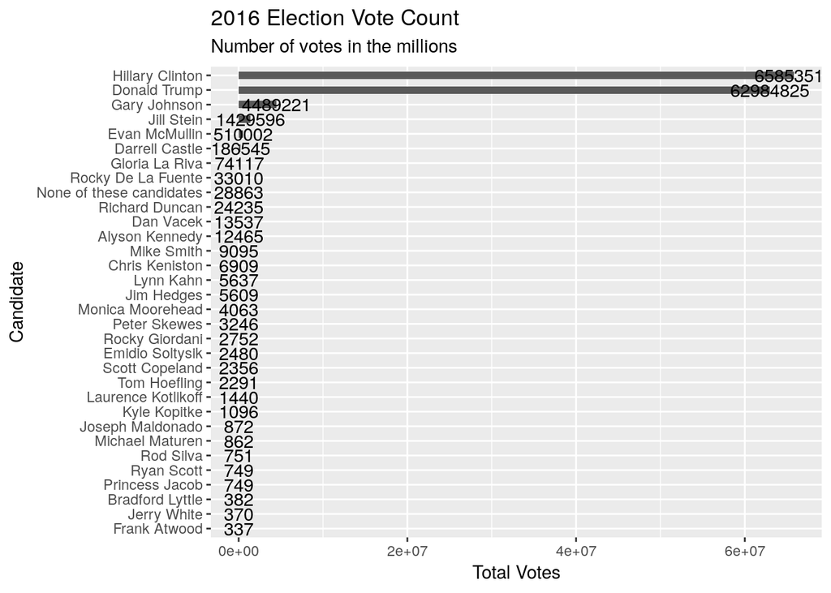

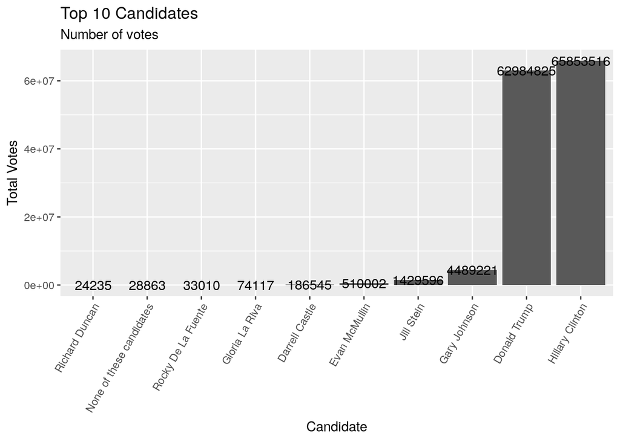

Even between the first 10 candidates, we see a huge disparity between candidate voting.

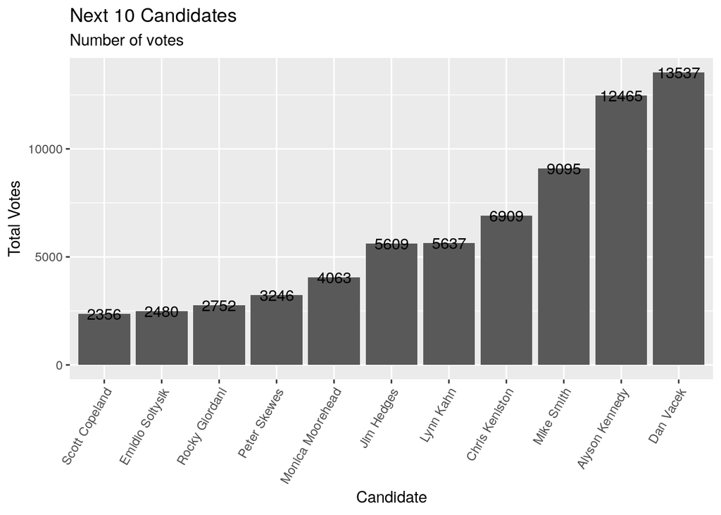

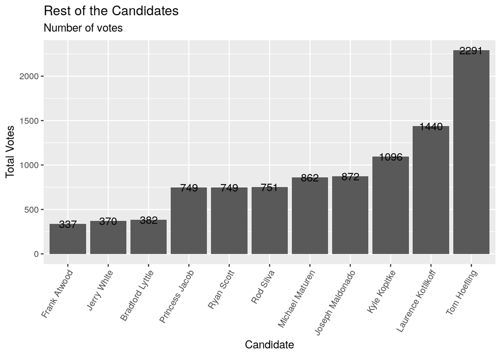

From the plots above we can clearly see it was a two horse race between Trump and Clinton. There were a total of 31 candidates in the 2016 election with a sufficient amount of votes,and over 28,000 votes going to “None of these” candidates.

```
## # A tibble: 6 x 5
##   county             fips  candidate       state   votes
##   <chr>              <chr> <fct>           <chr>   <int>
## 1 Los Angeles County 6037  Hillary Clinton CA    2464364
## 2 Los Angeles County 6037  Donald Trump    CA     769743
## 3 Los Angeles County 6037  Gary Johnson    CA      88968
## 4 Los Angeles County 6037  Jill Stein      CA      76465
## 5 Los Angeles County 6037  Gloria La Riva  CA      21993
## 6 Cook County        17031 Hillary Clinton IL    1611946
```

# Visualizing winner for each state

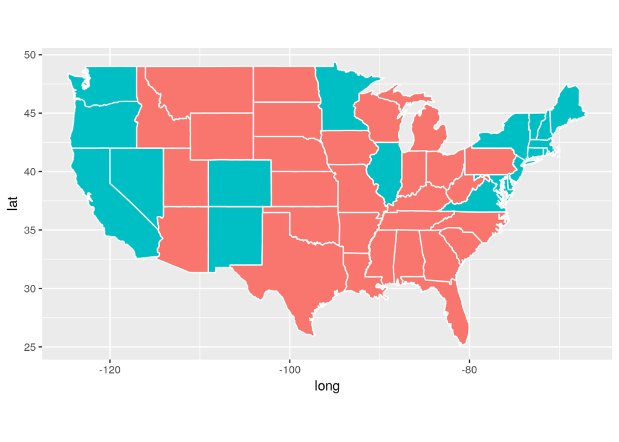

Blue states are states that were won by Hillary Clinton in the election, Red states going to Donald trump.

# County winner map of the US

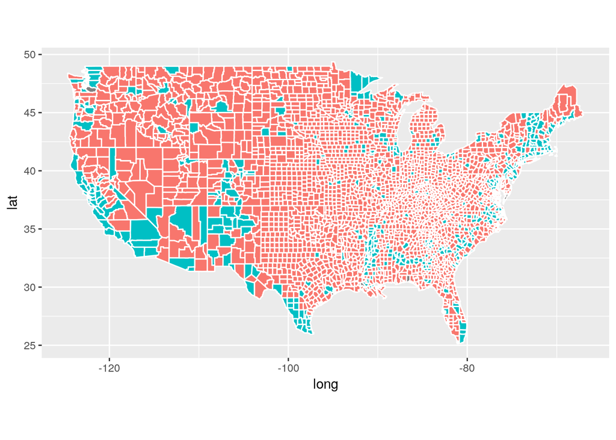

```r
ggplot(data = counties) +
  geom_polygon(aes(x = long, y = lat, fill = candidate, group = group), color = "white") +
  coord_fixed(1.3) +
  guides(fill=FALSE)
```

From the map above we can see that some counties were decisive winners, where other counties within states were split between the two candidates

# Visualizing Census Data

```
## [1] 62.03211
```

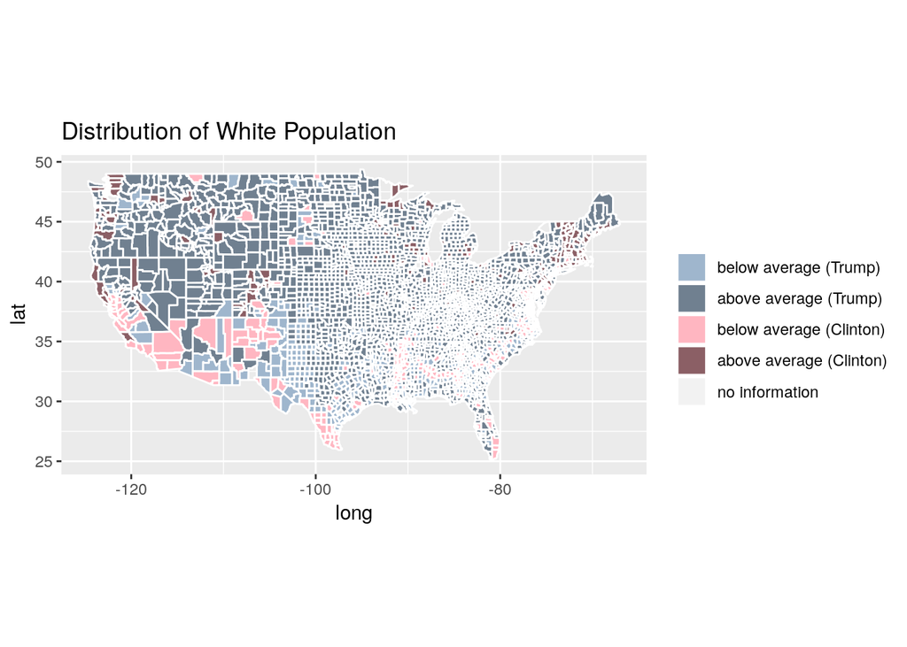

Our first map of the census data shows the average level of Whites for each county, grouped by the candidate they voted for. The grey colors represent Trump voters while the pink colors represent Clinton voters. Within those colors, the darker ones corresponds to above average levels and the lighter colors correspond to below the average level. From the map you can see that there were more Trump voters and out of Trump voters most were predominantly White, whereas the counties that voted for Clinton were below average White populated counties.

```
## [1] 57225.56
```

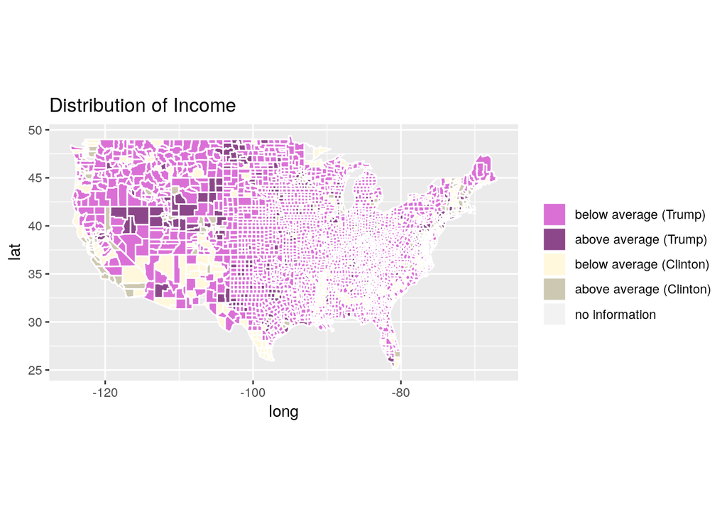

The following map visualizes the average income level of each county, grouped by who they voted for. The purple colors represents those who voted for Donald Trump while pale colors correspond to Clinton voters. The darker color of each group represents those counties that are above the federal income level while the lighter color of each group represents those counties that are below the federal level. From this data, we can say that majority of voters for both Trump and Clinton falls below average income, but Trump voters have more percentage of higher income supporters than those of Clinton.

# Cleaning Census Data

```
## # A tibble: 10 x 37
##    State County TotalPop   Men Women Hispanic White Black Native Asian
##    <chr> <chr>     <int> <dbl> <int>    <dbl> <dbl> <dbl>  <dbl> <dbl>
##  1 Alab… Autau…     1948  48.3  1008      0.9  87.4   7.7    0.3   0.6
##  2 Alab… Autau…     2156  49.1  1097      0.8  40.4  53.3    0     2.3
##  3 Alab… Autau…     2968  46.0  1604      0    74.5  18.6    0.5   1.4
##  4 Alab… Autau…     4423  49.1  2251     10.5  82.8   3.7    1.6   0
##  5 Alab… Autau…    10763  45.7  5841      0.7  68.5  24.8    0     3.8
##  6 Alab… Autau…     3851  46.4  2064     13.1  72.9  11.9    0     0
##  7 Alab… Autau…     2761  43.8  1551      3.8  74.5  19.7    0     0
##  8 Alab… Autau…     3187  47.1  1685      1.3  84    10.7    3.1   0
##  9 Alab… Autau…    10915  50.3  5429      1.4  89.5   8.4    0     0
## 10 Alab… Autau…     5668  51.1  2771      0.4  85.5  12.1    0     0.3
## # ... with 27 more variables: Pacific <dbl>, Citizen <dbl>, Income <int>,
## #   IncomeErr <int>, IncomePerCap <int>, IncomePerCapErr <int>,
## #   Poverty <dbl>, ChildPoverty <dbl>, Professional <dbl>, Service <dbl>,
## #   Office <dbl>, Construction <dbl>, Production <dbl>, Drive <dbl>,
## #   Carpool <dbl>, Transit <dbl>, Walk <dbl>, OtherTransp <dbl>,
## #   WorkAtHome <dbl>, MeanCommute <dbl>, Employed <dbl>,
## #   PrivateWork <dbl>, PublicWork <dbl>, SelfEmployed <dbl>,
## #   FamilyWork <dbl>, Unemployment <dbl>, Minority <dbl>
```

| State | County | Men | Women | Hispanic | White | Black | Native | Asian | Pacific | Citizen | Income | IncomeErr | IncomePerCap | IncomePerCapErr | Poverty | ChildPoverty | Professional | Service | Office | Construction | Production | Drive | Carpool | Transit | Walk | OtherTransp | WorkAtHome | MeanCommute | Employed | … |
| --- | --- | --- | --- | --- | --- | --- | --- | --- | --- | --- | --- | --- | --- | --- | --- | --- | --- | --- | --- | --- | --- | --- | --- | --- | --- | --- | --- | --- | --- | --- |
| Alabama | Autauga | 48.43266 | 3348.805 | 2.614243 | 75.78823 | 18.526968 | 0.4218812 | 0.9576538 | 0.0161243 | 73.74912 | 51696.29 | 7771.009 | 24974.50 | 3433.674 | 12.91231 | 18.70758 | 32.79097 | 17.17044 | 24.28243 | 8.570136 | 17.15713 | 87.50624 | 8.781235 | 0.0952590 | 0.4700983 | 1.3059687 | 1.8356531 | 26.50016 | 43.43637 | … |
| Alabama | Baldwin | 48.84866 | 3934.167 | 4.493247 | 83.10262 | 9.496849 | 0.5594682 | 0.6646963 | 0.0000000 | 75.69406 | 51074.36 | 8745.050 | 27316.84 | 3803.718 | 13.42423 | 19.48431 | 32.72994 | 17.95092 | 27.10439 | 10.895958 | 11.32186 | 84.59861 | 8.959078 | 0.1266209 | 1.0218408 | 1.4438000 | 3.8504774 | 26.32218 | 44.05113 | … |
| Alabama | Barbour | 53.82816 | 1491.941 | 4.628312 | 46.23159 | 46.690624 | 0.1881405 | 0.4367407 | 0.0000000 | 76.91222 | 32959.30 | 6031.065 | 16824.22 | 2430.189 | 26.50563 | 43.55962 | 26.12404 | 16.46343 | 23.27878 | 10.824870 | 23.31741 | 83.33021 | 11.056609 | 0.4954032 | 1.9734479 | 1.6217251 | 1.5019456 | 24.51828 | 31.92113 | … |
| Alabama | Bibb | 53.41090 | 2930.106 | 2.209158 | 74.49989 | 21.425137 | 0.4310697 | 0.1006061 | 0.0000000 | 77.39781 | 38886.63 | 5662.358 | 18430.99 | 3073.599 | 16.60375 | 27.19708 | 21.59010 | 17.95545 | 17.46731 | 19.245868 | 23.74415 | 83.43488 | 13.153641 | 0.5031366 | 0.6235135 | 1.5620952 | 0.7314679 | 28.71439 | 36.69262 | … |
| Alabama | Blount | 49.40565 | 3562.081 | 8.634816 | 87.85385 | 1.520305 | 0.2911748 | 0.1484491 | 0.0000000 | 73.37550 | 46237.97 | 8695.786 | 20532.27 | 2052.055 | 16.72152 | 26.85738 | 28.52930 | 13.94252 | 23.83692 | 13.602372 | 20.10413 | 84.85031 | 11.279222 | 0.3626321 | 0.8386363 | 0.4199411 | 2.2654133 | 34.84489 | 38.44914 | … |
| Alabama | Bullock | 53.00618 | 1968.034 | 4.450815 | 22.19918 | 70.721099 | 1.1635700 | 0.2003840 | 0.0000000 | 75.45420 | 33292.69 | 9000.345 | 17579.57 | 3110.645 | 24.50260 | 37.29116 | 19.55253 | 14.92420 | 20.17051 | 19.598661 | 25.73547 | 74.77277 | 14.839127 | 0.7732160 | 4.6653119 | 1.8238247 | 3.0998783 | 28.63106 | 36.19592 | … |

We cleaned up census data mutating redundant columns, and aggregated all the subcounties into single county rows.

# Principal Component Analysis

```
## [1] "IncomePerCap" "Income"       "ChildPoverty"
```

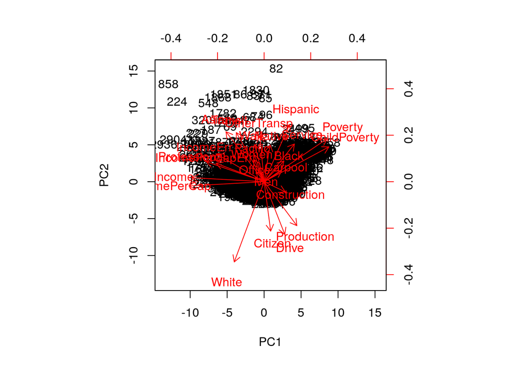

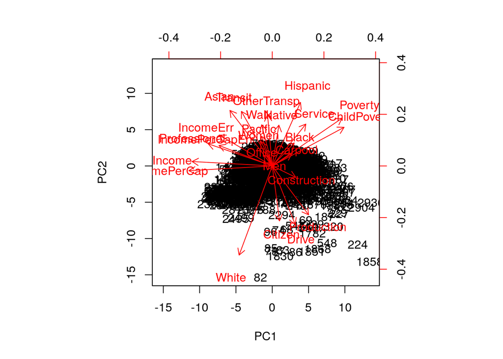

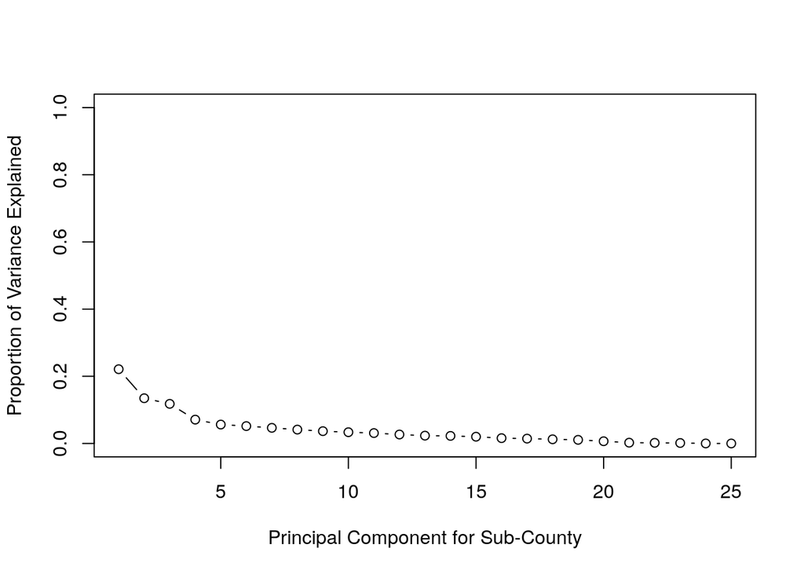

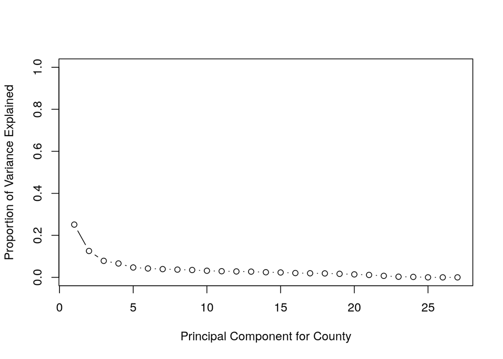

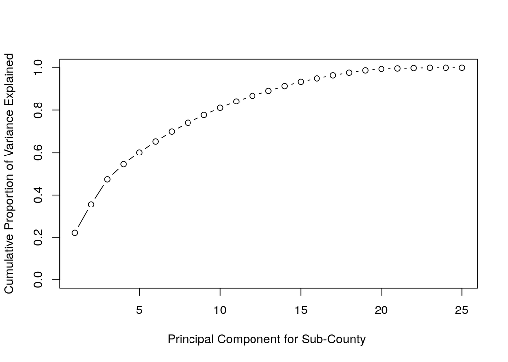

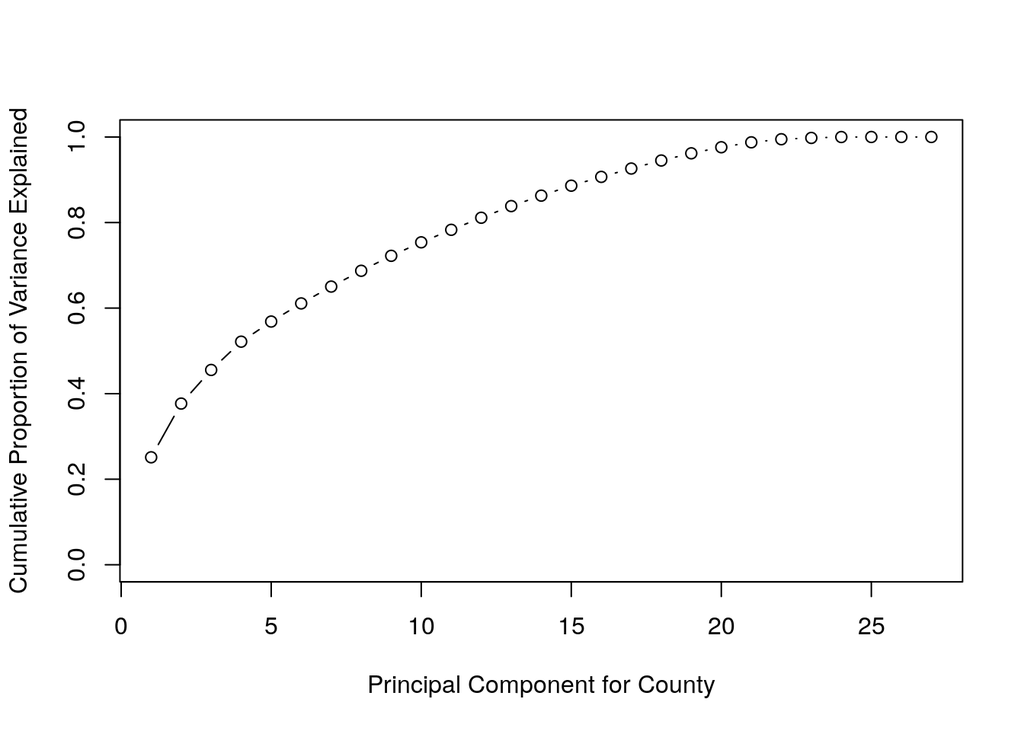

# Clustering

```
## [1] 4
```

```
## [1] 9
```

```
## # A tibble: 134 x 38
##    State County   Men Women Hispanic White  Black Native  Asian Pacific
##    <chr> <chr>  <dbl> <dbl>    <dbl> <dbl>  <dbl>  <dbl>  <dbl>   <dbl>
##  1 Alas… Hoona…  53.1  941.     2.23  49.3  2.23  32.4    2.62    0
##  2 Alas… Kodia…  53.4 2033.     8.50  51.4  0.440 13.3   21.3     0.884
##  3 Alas… Peter…  53.0 1513      9.4   68.6  3      5.9    2.3     0.4
##  4 Alas… Princ…  54.5  986.     3.20  45.8  0.192 40.4    0.746   0.264
##  5 Alas… Sitka…  51.3 2305.     6.05  62.7  1.07  13.6    5.76    0.335
##  6 Alas… Skagw…  52.8  472      4.5   75.3  0      5     10.6     0
##  7 Alas… Valde…  53.4 1598.     4.42  70.1  0     14.8    3.21    0.434
##  8 Alas… Wrang…  51.4 1160      1.4   68.5  0.2   17.3    2.5     0
##  9 Alas… Yakut…  57.1  276      2.6   39.3  1.4   32.2    6.7     1.2
## 10 Cali… Alame…  49.0 2542.    22.6   33.0 11.3    0.304 27.5     0.838
## # ... with 124 more rows, and 28 more variables: Citizen <dbl>,
## #   Income <dbl>, IncomeErr <dbl>, IncomePerCap <dbl>,
## #   IncomePerCapErr <dbl>, Poverty <dbl>, ChildPoverty <dbl>,
## #   Professional <dbl>, Service <dbl>, Office <dbl>, Construction <dbl>,
## #   Production <dbl>, Drive <dbl>, Carpool <dbl>, Transit <dbl>,
## #   Walk <dbl>, OtherTransp <dbl>, WorkAtHome <dbl>, MeanCommute <dbl>,
## #   Employed <dbl>, PrivateWork <dbl>, PublicWork <dbl>,
## #   SelfEmployed <dbl>, FamilyWork <dbl>, Unemployment <dbl>,
## #   Minority <dbl>, total <dbl>, Cluster <int>
```

```
## # A tibble: 21 x 38
##    State County   Men Women Hispanic White Black Native Asian Pacific
##    <chr> <chr>  <dbl> <dbl>    <dbl> <dbl> <dbl>  <dbl> <dbl>   <dbl>
##  1 Cali… Alame…  49.0 2542.    22.6   33.0 11.3  0.304  27.5   0.838
##  2 Cali… Marin   48.3 2764.    15.7   72.7  1.94 0.158   5.64  0.154
##  3 Cali… San M…  49.2 2757.    25.4   40.6  2.48 0.116  26.2   1.37
##  4 Cali… Santa…  50.3 2771.    26.6   33.6  2.41 0.188  33.5   0.333
##  5 Colo… Pitkin  53.0 2587.     9.69  86.3  1.24 0.199   1.44  0
##  6 Conn… Fairf…  48.7 2582.    18.8   63.2 10.7  0.144   5.06  0.0316
##  7 Dist… Distr…  47.2 2180.    10.2   35.3 48.4  0.196   3.49  0.0348
##  8 Mary… Howard  49.0 3051.     6.26  56.1 17.8  0.203  16.2   0.0449
##  9 Mary… Montg…  48.2 2772.    18.4   46.2 17.3  0.154  14.6   0.0341
## 10 Mass… Middl…  48.7 2797.     7.31  74.7  4.58 0.0900 10.5   0.0200
## # ... with 11 more rows, and 28 more variables: Citizen <dbl>,
## #   Income <dbl>, IncomeErr <dbl>, IncomePerCap <dbl>,
## #   IncomePerCapErr <dbl>, Poverty <dbl>, ChildPoverty <dbl>,
## #   Professional <dbl>, Service <dbl>, Office <dbl>, Construction <dbl>,
## #   Production <dbl>, Drive <dbl>, Carpool <dbl>, Transit <dbl>,
## #   Walk <dbl>, OtherTransp <dbl>, WorkAtHome <dbl>, MeanCommute <dbl>,
## #   Employed <dbl>, PrivateWork <dbl>, PublicWork <dbl>,
## #   SelfEmployed <dbl>, FamilyWork <dbl>, Unemployment <dbl>,
## #   Minority <dbl>, total <dbl>, Cluster <int>
```

# Decision tree

```
##        Length Class  Mode
## size   12     -none- numeric
## dev    12     -none- numeric
## k      12     -none- numeric
## method  1     -none- character
```

```
## [1] 15
```

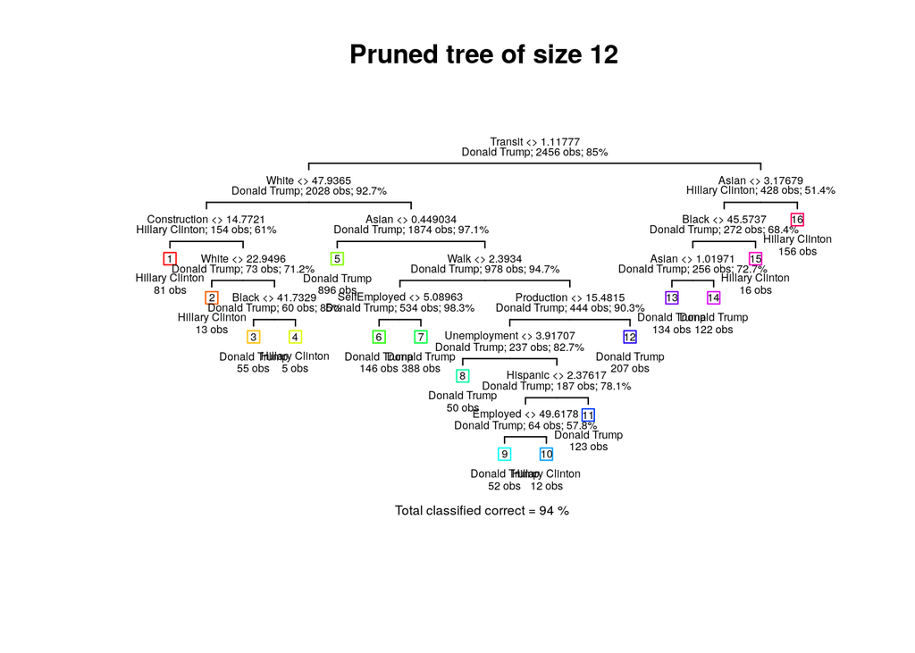

# Logistic Regression

# Lasso Classifier

The most optimal value of $\lambda$ acquired through cross-validation methods is 0.001. This is the penalty coefficient for a lasso classifier.

```
##  [1] "(Intercept)"     "total_votes"     "White"
##  [4] "Black"           "Native"          "Asian"
##  [7] "Pacific"         "Citizen"         "IncomeErr"
## [10] "IncomePerCap"    "IncomePerCapErr" "Poverty"
## [13] "Professional"    "Service"         "Office"
## [16] "Construction"    "Drive"           "Carpool"
## [19] "Transit"         "Walk"            "WorkAtHome"
## [22] "MeanCommute"     "Employed"        "PrivateWork"
## [25] "PublicWork"      "FamilyWork"      "Unemployment"
```

```
##           features  nonzerocoefs
## 1      (Intercept)  1.327369e+01
## 2      total_votes -7.021579e-07
## 3            White  1.162031e-01
## 4            Black -8.736506e-03
## 5           Native  3.153577e-02
## 6            Asian -1.062109e-01
## 7          Pacific -8.450452e-01
## 8          Citizen -1.188603e-01
## 9        IncomeErr  5.000773e-05
## 10    IncomePerCap -9.942182e-05
## 11 IncomePerCapErr  6.448418e-05
## 12         Poverty -3.995307e-02
## 13    Professional -7.716171e-02
## 14         Service -1.502604e-01
## 15          Office  4.888305e-02
## 16    Construction  1.313939e-01
## 17           Drive  6.332136e-02
## 18         Carpool  5.063829e-02
## 19         Transit -1.500319e-01
## 20            Walk -1.088123e-01
## 21      WorkAtHome -1.547360e-02
## 22     MeanCommute -6.555053e-03
## 23        Employed -1.419268e-01
## 24     PrivateWork -4.061447e-02
## 25      PublicWork  1.644958e-02
## 26      FamilyWork  6.921284e-01
## 27    Unemployment -1.426274e-01
```

# ROC Curves

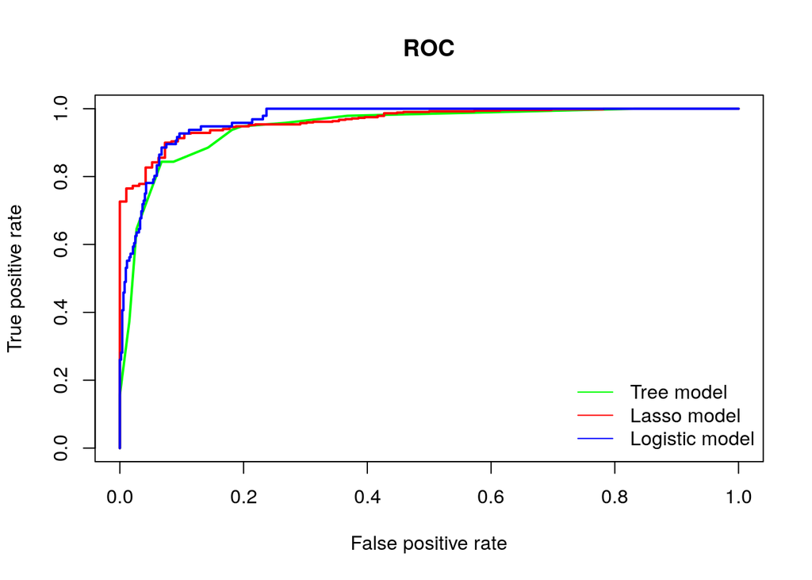

ROC curves depict the trade of between false hits rates and false alarm rate. The graph above is a comparison between our three models.

|  | AUC |
| --- | --- |
| tree | 0.946511721258831 |
| logistic | 0.966983782915863 |
| lasso | 0.96174533444 |

In terms of AUC, our logistic regression classifier performed the best. Our logistic classifier has the greatest ability to show a constant difference between in our data with different labels, for example the percentage of whites in a county/state would be placed as a greater importance than income.

|  | train.error | test.error |
| --- | --- | --- |
| tree | 0.0602606 | 0.0780488 |
| logistic | 0.0627036 | 0.0813008 |
| lasso | 0.0643322 | 0.0845528 |

Our decision tree classifier yieled the highest prediction accuracy rate between the three. While the lasso model was slightly out performed by the logistic model. This is because when picking our $\lambda$, we we were constrained to four choices.

All three models has its pros and cons. If we just wanted to predict the election, the decision tree would surely be the best option. Decision trees are also very easy to interpret in terms of the demographic of voters whom are voting for either Donald Trump or Hillary Clinton.

# How would other classification methods do?

For this part of the report we will look at three different classifiers, random forest, support vector machines, and quadratic discriminant analysis.

## Random Forest

We will use the random forest classifier on our data.

```r
#Random Forest Model
rf.voting
```

```
##
## Call:
##  randomForest(formula = candidate ~ ., data = train.cl, mtry = 8,      ntree = 500, importance = TRUE)
##                Type of random forest: classification
##                      Number of trees: 500
## No. of variables tried at each split: 8
##
##         OOB estimate of  error rate: 5.62%
## Confusion matrix:
##                 Donald Trump Hillary Clinton class.error
## Donald Trump            2051              36  0.01724964
## Hillary Clinton          102             267  0.27642276
```

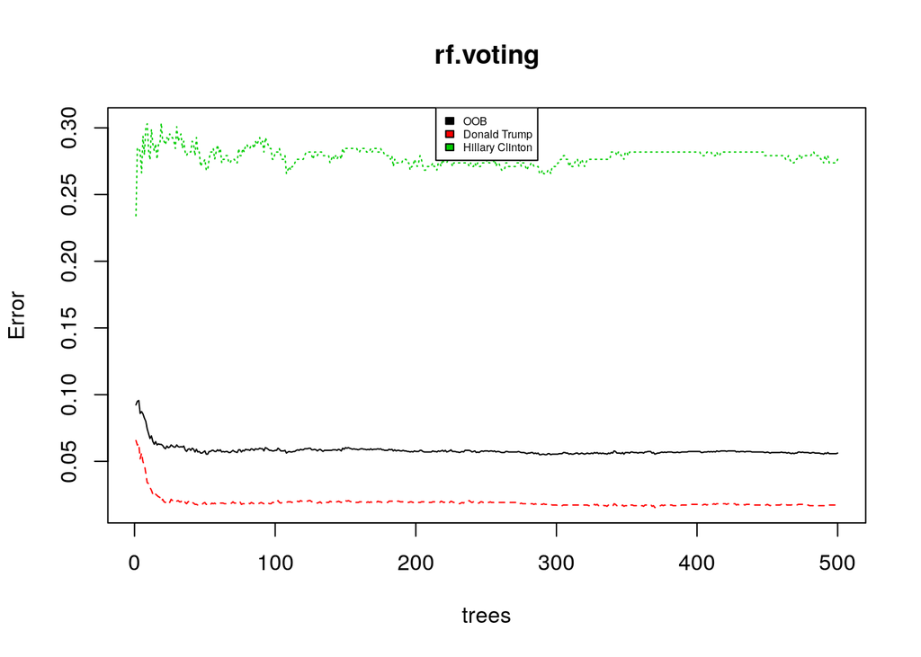

Our training error decreases as more trees are grown in our random forest model.

```
##                 Donald Trump Hillary Clinton MeanDecreaseAccuracy
## total_votes       22.5754256      19.2720014            28.459613
## Men                4.6133127       5.9964039             7.327852
## Women             11.6490306       4.5189583            12.782207
## Hispanic          13.2263637       8.7800661            16.618836
## White             21.8473442      25.8021320            27.603124
## Black             19.2544612      20.0332367            23.322978
## Native             4.9225660       9.8216883            10.727134
## Asian             13.1548970      21.2539077            24.345477
## Pacific            0.4738842       6.4901090             6.668303
## Citizen            9.0960535       8.1063758            11.710627
## Income            10.0255090       6.1556381            11.862007
## IncomeErr          1.8197299       7.9404837             7.568424
## IncomePerCap       9.9744207       9.5589012            14.210745
## IncomePerCapErr    3.1017245       9.2910185            10.866886
## Poverty           10.8406828       2.1435962            11.196989
## ChildPoverty       8.5487788       2.0609790             9.326201
## Professional      10.8805684       9.8522655            13.705980
## Service            8.7930059       8.1237609            11.899296
## Office            10.4998124      -0.4682537            10.074536
## Construction      21.1777246      19.6675830            27.387975
## Production         8.8581912      11.2063103            14.245776
## Drive             11.1388028      10.9667852            15.117184
## Carpool            4.8857778       3.9086756             6.604513
## Transit            2.7789297      39.1686911            34.923721
## Walk              10.3545237      10.7610338            13.976993
## OtherTransp        1.3659890      10.0409882             9.339458
## WorkAtHome         9.3312462      10.0657827            13.108979
## MeanCommute       10.2320135       6.3023418            12.376229
## Employed           7.9764218      12.8513689            12.405615
## PrivateWork        7.5874014       1.3698704             7.989915
## PublicWork         6.4109255       2.9267619             7.174922
## SelfEmployed       7.5938733       6.7109416            10.050810
## FamilyWork         2.0830466       4.5566377             4.925694
## Unemployment       9.1132231      12.4385525            15.360254
## Minority          20.8395489      24.8094569            27.684727
##                 MeanDecreaseGini
## total_votes            43.253804
## Men                     7.284535
## Women                   7.849004
```

[output cut: 17 more lines]

```
## Production             11.274044
## Drive                  11.746012
## Carpool                 5.766281
## Transit                72.062400
## Walk                   11.040866
## OtherTransp             8.238240
## WorkAtHome              8.095724
## MeanCommute             8.031410
## Employed               10.637152
## PrivateWork             5.031544
## PublicWork              5.682683
## SelfEmployed            8.464077
## FamilyWork              4.468479
## Unemployment           12.935314
## Minority               59.921643
```

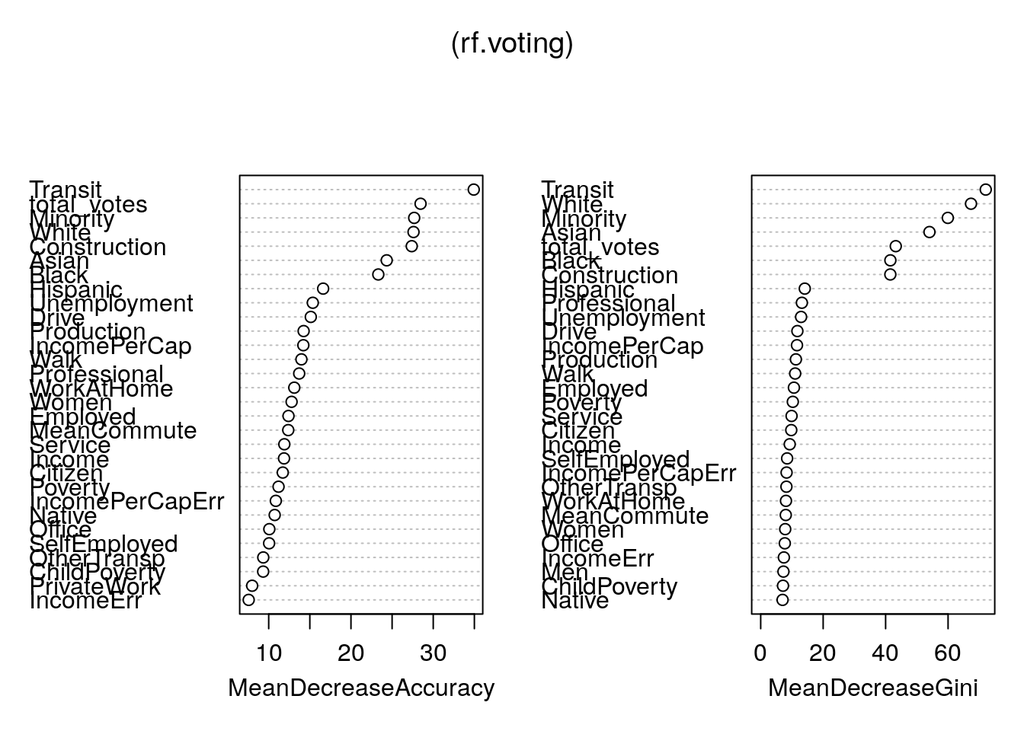

|  | test.error |
| --- | --- |
| random forest | 0.0504065 |
| svm | NA |
| qda | NA |

Our model performed significantly better than our lasso, logistic, and decision tree classifier.

# Support Vector Machines

```
##
## Call:
## svm(formula = candidate ~ ., data = train.cl, kernel = "linear",
##     cost = 10, scale = TRUE)
##
##
## Parameters:
##    SVM-Type:  C-classification
##  SVM-Kernel:  linear
##        cost:  10
##       gamma:  0.02857143
##
## Number of Support Vectors:  420
```

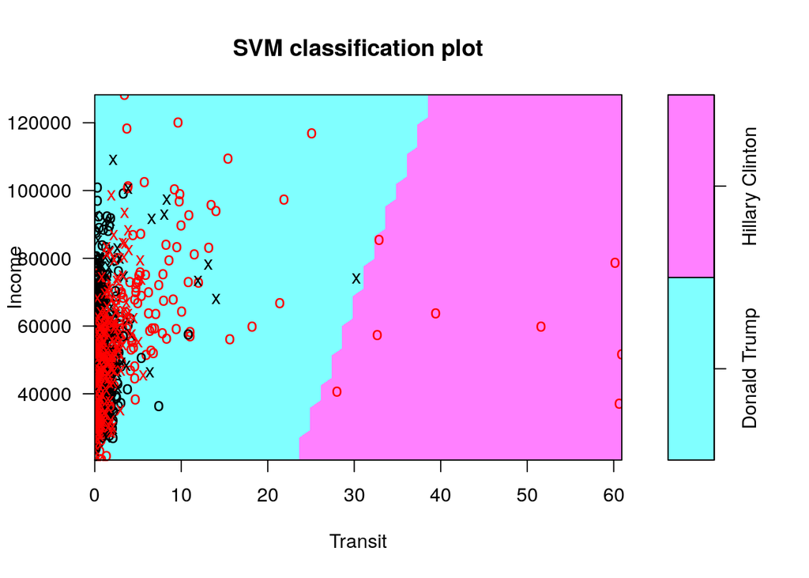

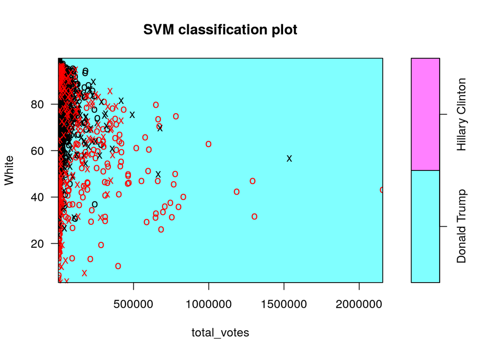

```r
#Support vector model
summary(svm.mod)
```

```
##
## Call:
## svm(formula = candidate ~ ., data = train.cl, kernel = "linear",
##     cost = 10, scale = TRUE)
##
##
## Parameters:
##    SVM-Type:  C-classification
##  SVM-Kernel:  linear
##        cost:  10
##       gamma:  0.02857143
##
## Number of Support Vectors:  420
##
##  ( 215 205 )
##
##
## Number of Classes:  2
##
## Levels:
##  Donald Trump Hillary Clinton
```

|  | test.error |
| --- | --- |
| random forest | 0.0504065 |
| svm | 0.0861789 |
| qda | NA |

# Quadratic Discriminant Analysis

Now, we will use a quadratic analysis classifier on our election data.

|  | test.error |
| --- | --- |
| random forest | 0.0504065 |
| svm | 0.0861789 |
| qda | 0.0953344 |

The figure above shows us that QDA did the worst out of these three models.QDA was also outperformed by our logistic,lasso, and decision tree classifier.

# Conclusion

We also performed hierarchical clustering with complete linkage on two sets of data; original and the same set of data that has been through principal component analysis. Through that we concluded the PCA data displayed better clustering. By applying principal component analysis before clustering improves noise reduction and eliminates low variance dimension. By dimension reduction, PCA also sets everything into the same scale and also reduces number of features but emphasizes variance, and reduction of mean squared error.